# Environments dplyr, tidyr and some SQLite

May 25, 2021

## How to Navigate this Slide Show?

- This **ioslides** presentation contains scrollable slides.
- Which slides are scrollable, is indicated by a tag at the bottom of the corresponding slides stating:

**[ Scroll down to continue ]**

- The following single character keyboard shortcuts enable alternate display modes of **ioslides**:
  - `f`: enable fullscreen mode
  - `w`: toggle widescreen mode
  - `o`: enable overview mode
  - `h`: enable code highlight mode
- Pressing Esc exits all of these modes. Additional details can be found [here](https://bookdown.org/yihui/rmarkdown/ioslides-presentation.html).

## Outline

- **Overview**
- Install
- File Import and Export
- Usage
- Chaining (Pipes)
- SQLite Databases
- References

## Overview

Modern object classes and methods for handling `data.frame` like structures are provided by the `dplyr` (`tidyr`) and `data.table` packages. A related example is Bioconductor’s `DataTable` object class. This tutorial provide a short introduction to the usage and functionalities of the `dplyr` and related packages.

### Related documentation

More detailed tutorials on this topic can be found here:

- [dplyr: A Grammar of Data Manipulation](https://rdrr.io/cran/dplyr/)
- [Introduction to `dplyr`](https://cran.r-project.org/web/packages/dplyr/vignettes/dplyr.html)
- [Tutorial on `dplyr`](http://genomicsclass.github.io/book/pages/dplyr_tutorial.html)
- [Cheatsheet for Joins from Jenny Bryan](http://stat545.com/bit001_dplyr-cheatsheet.html)
- [Tibbles](https://cran.r-project.org/web/packages/tibble/vignettes/tibble.html)
- [Intro to `data.table` package](https://www.r-bloggers.com/intro-to-the-data-table-package/)
- [Big data with `dplyr` and `data.table`](https://www.r-bloggers.com/working-with-large-datasets-with-dplyr-and-data-table/)
- [Fast lookups with `dplyr` and `data.table`](https://www.r-bloggers.com/fast-data-lookups-in-r-dplyr-vs-data-table/)

## Outline

- Overview
- **Install**
- File Import and Export
- Usage
- Chaining (Pipes)
- SQLite
- References

## Installation

The `dplyr` (`tidyr`) environment has evolved into an ecosystem of packages. To simplify package management, one can install and load the entire collection via the `tidyverse` package ( “ Learn the tidyverse,” n.d.). For more details on `tidyverse` see [here](http://tidyverse.org/).

```r
install.packages("tidyverse")
```

Load `tidyverse` package environment

```r
library(tidyverse)
```

## Outline

- Overview
- Install
- **File Import and Export**
- Usage
- Chaining (Pipes)
- SQLite Databases
- References

## Construct objects

### Construct a `tibble`

```r
as_tibble(iris) # coerce data.frame to tibble tbl
```

| Sepal.Length | Sepal.Width | Petal.Length | Petal.Width | Species |
| --- | --- | --- | --- | --- |
| 5.1 | 3.5 | 1.4 | 0.2 | setosa |
| 4.9 | 3.0 | 1.4 | 0.2 | setosa |
| 4.7 | 3.2 | 1.3 | 0.2 | setosa |
| 4.6 | 3.1 | 1.5 | 0.2 | setosa |
| 5.0 | 3.6 | 1.4 | 0.2 | setosa |
| 5.4 | 3.9 | 1.7 | 0.4 | setosa |
| 4.6 | 3.4 | 1.4 | 0.3 | setosa |
| 5.0 | 3.4 | 1.5 | 0.2 | setosa |
| 4.4 | 2.9 | 1.4 | 0.2 | setosa |
| 4.9 | 3.1 | 1.5 | 0.1 | setosa |

[output cut: 140 more lines]

Alternative function producing the same result include `tbl_df` and `as_data_frame` (latter has been deprecated):

```r
tbl_df(iris)
```

## Reading and writing tabular files

While the base R read/write utilities can be used for `data.frames`, best time performance with the least amount of typing is achieved with the export/import functions from the `readr` package. For very large files the `fread` function from the `data.table` package achieves the best time performance.

### Import with `readr`

Import functions provided by `readr` include:

- `read_csv()`: comma separated (CSV) files
- `read_tsv()`: tab separated files
- `read_delim()`: general delimited files
- `read_fwf()`: fixed width files
- `read_table()`: tabular files where colums are separated by white-space.
- `read_log()`: web log files

**[ scroll down to continue ]**

Create a sample tab delimited file for import

```r
write_tsv(iris, "iris.txt") # Creates sample file
```

Import with `read_tsv`

```r
iris_df <- read_tsv("iris.txt") # Import with read_tbv from readr package
iris_df
```

| Sepal.Length | Sepal.Width | Petal.Length | Petal.Width | Species |
| --- | --- | --- | --- | --- |
| 5.1 | 3.5 | 1.4 | 0.2 | setosa |
| 4.9 | 3.0 | 1.4 | 0.2 | setosa |
| 4.7 | 3.2 | 1.3 | 0.2 | setosa |
| 4.6 | 3.1 | 1.5 | 0.2 | setosa |
| 5.0 | 3.6 | 1.4 | 0.2 | setosa |
| 5.4 | 3.9 | 1.7 | 0.4 | setosa |
| 4.6 | 3.4 | 1.4 | 0.3 | setosa |
| 5.0 | 3.4 | 1.5 | 0.2 | setosa |
| 4.4 | 2.9 | 1.4 | 0.2 | setosa |
| 4.9 | 3.1 | 1.5 | 0.1 | setosa |

[output cut: 140 more lines]

To import Google Sheets directly into R, see [here](https://girke.bioinformatics.ucr.edu/GEN242/tutorials/rbasics/rbasics/#reading-and-writing-external-data).

### Fast table import with `fread`

The `fread` function from the `data.table` package provides the best time performance for reading large tabular files into R.

```r
library(data.table)
iris_df <- as_data_frame(fread("iris.txt")) # Import with fread and conversion to tibble
iris_df
```

| Sepal.Length | Sepal.Width | Petal.Length | Petal.Width | Species |
| --- | --- | --- | --- | --- |
| 5.1 | 3.5 | 1.4 | 0.2 | setosa |
| 4.9 | 3.0 | 1.4 | 0.2 | setosa |
| 4.7 | 3.2 | 1.3 | 0.2 | setosa |
| 4.6 | 3.1 | 1.5 | 0.2 | setosa |
| 5.0 | 3.6 | 1.4 | 0.2 | setosa |
| 5.4 | 3.9 | 1.7 | 0.4 | setosa |
| 4.6 | 3.4 | 1.4 | 0.3 | setosa |
| 5.0 | 3.4 | 1.5 | 0.2 | setosa |
| 4.4 | 2.9 | 1.4 | 0.2 | setosa |
| 4.9 | 3.1 | 1.5 | 0.1 | setosa |

[output cut: 140 more lines]

Note: to ignore lines starting with comment signs, one can pass on to `fread` a shell command for preprocessing the file. The following example illustrates this option.

```r
fread("grep -v '^#' iris.txt")
```

### Export with `readr`

Export function provided by `readr` inlcude

- `write_delim()`: general delimited files
- `write_csv()`: comma separated (CSV) files
- `write_excel_csv()`: excel style CSV files
- `write_tsv()`: tab separated files

For instance, the `write_tsv` function writes a `data.frame` or `tibble` to a tab delimited file with much nicer default settings than the base R `write.table` function.

```r
write_tsv(iris_df, "iris.txt")
```

## Outline

- Overview
- Install
- File Import and Export
- **Usage**
- Chaining (Pipes)
- SQLite Databases
- References

## How to use `tibbles`?

### Column and row binds

The equivalents to base R’s `rbind` and `cbind` are `bind_rows` and `bind_cols`, respectively.

```r
bind_cols(iris_df, iris_df)[1:2,]
```

```
## * Sepal.Length -> Sepal.Length...1
## * Sepal.Width -> Sepal.Width...2
## * Petal.Length -> Petal.Length...3
## * Petal.Width -> Petal.Width...4
## * Species -> Species...5
## * ...
```

| Sepal.Length...1 | Sepal.Width...2 | Petal.Length...3 | Petal.Width...4 | Species...5 | Sepal.Length...6 | Sepal.Width...7 | Petal.Length...8 | Petal.Width...9 | Species...10 |
| --- | --- | --- | --- | --- | --- | --- | --- | --- | --- |
| 5.1 | 3.5 | 1.4 | 0.2 | setosa | 5.1 | 3.5 | 1.4 | 0.2 | setosa |
| 4.9 | 3.0 | 1.4 | 0.2 | setosa | 4.9 | 3.0 | 1.4 | 0.2 | setosa |

**[ scroll down to continue ]**

```r
bind_rows(iris_df, iris_df)[1:2,]
```

| Sepal.Length | Sepal.Width | Petal.Length | Petal.Width | Species |
| --- | --- | --- | --- | --- |
| 5.1 | 3.5 | 1.4 | 0.2 | setosa |
| 4.9 | 3.0 | 1.4 | 0.2 | setosa |

### Extract column as vector

The subsetting operators `[[` and `$`can be used to extract from a `tibble` single columns as vector.

```r
iris_df[[5]][1:12]
```

```
##  [1] "setosa" "setosa" "setosa" "setosa" "setosa" "setosa" "setosa" "setosa"
##  [9] "setosa" "setosa" "setosa" "setosa"
```

```r
iris_df$Species[1:12]
```

```
##  [1] "setosa" "setosa" "setosa" "setosa" "setosa" "setosa" "setosa" "setosa"
##  [9] "setosa" "setosa" "setosa" "setosa"
```

### Important `dplyr` functions

1. `filter()` and `slice()`
2. `arrange()`
3. `select()` and `rename()`
4. `distinct()`
5. `mutate()` and `transmute()`
6. `summarise()`
7. `sample_n()` and `sample_frac()`

### Slice and filter functions

### Filter function

```r
filter(iris_df, Sepal.Length > 7.5, Species=="virginica")
```

| Sepal.Length | Sepal.Width | Petal.Length | Petal.Width | Species |
| --- | --- | --- | --- | --- |
| 7.6 | 3.0 | 6.6 | 2.1 | virginica |
| 7.7 | 3.8 | 6.7 | 2.2 | virginica |
| 7.7 | 2.6 | 6.9 | 2.3 | virginica |
| 7.7 | 2.8 | 6.7 | 2.0 | virginica |
| 7.9 | 3.8 | 6.4 | 2.0 | virginica |
| 7.7 | 3.0 | 6.1 | 2.3 | virginica |

### Base R code equivalent

```r
iris_df[iris_df[, "Sepal.Length"] > 7.5 & iris_df[, "Species"]=="virginica", ]
```

| Sepal.Length | Sepal.Width | Petal.Length | Petal.Width | Species |
| --- | --- | --- | --- | --- |
| 7.6 | 3.0 | 6.6 | 2.1 | virginica |
| 7.7 | 3.8 | 6.7 | 2.2 | virginica |
| 7.7 | 2.6 | 6.9 | 2.3 | virginica |
| 7.7 | 2.8 | 6.7 | 2.0 | virginica |
| 7.9 | 3.8 | 6.4 | 2.0 | virginica |
| 7.7 | 3.0 | 6.1 | 2.3 | virginica |

### Including boolean operators

```r
filter(iris_df, Sepal.Length > 7.5 | Sepal.Length < 5.5, Species=="virginica")
```

| Sepal.Length | Sepal.Width | Petal.Length | Petal.Width | Species |
| --- | --- | --- | --- | --- |
| 7.6 | 3.0 | 6.6 | 2.1 | virginica |
| 4.9 | 2.5 | 4.5 | 1.7 | virginica |
| 7.7 | 3.8 | 6.7 | 2.2 | virginica |
| 7.7 | 2.6 | 6.9 | 2.3 | virginica |
| 7.7 | 2.8 | 6.7 | 2.0 | virginica |
| 7.9 | 3.8 | 6.4 | 2.0 | virginica |
| 7.7 | 3.0 | 6.1 | 2.3 | virginica |

### Subset rows by position

`dplyr` approach

```r
slice(iris_df, 1:2)
```

| Sepal.Length | Sepal.Width | Petal.Length | Petal.Width | Species |
| --- | --- | --- | --- | --- |
| 5.1 | 3.5 | 1.4 | 0.2 | setosa |
| 4.9 | 3.0 | 1.4 | 0.2 | setosa |

Base R code equivalent

```r
iris_df[1:2,]
```

| Sepal.Length | Sepal.Width | Petal.Length | Petal.Width | Species |
| --- | --- | --- | --- | --- |
| 5.1 | 3.5 | 1.4 | 0.2 | setosa |
| 4.9 | 3.0 | 1.4 | 0.2 | setosa |

### Subset rows by names

Create a suitable test `tibble`

```r
df1 <- bind_cols(data_frame(ids1=paste0("g", 1:10)), as_data_frame(matrix(1:40, 10, 4, dimnames=list(1:10, paste0("CA", 1:4)))))
df1
```

| ids1 | CA1 | CA2 | CA3 | CA4 |
| --- | --- | --- | --- | --- |
| g1 | 1 | 11 | 21 | 31 |
| g2 | 2 | 12 | 22 | 32 |
| g3 | 3 | 13 | 23 | 33 |
| g4 | 4 | 14 | 24 | 34 |
| g5 | 5 | 15 | 25 | 35 |
| g6 | 6 | 16 | 26 | 36 |
| g7 | 7 | 17 | 27 | 37 |
| g8 | 8 | 18 | 28 | 38 |
| g9 | 9 | 19 | 29 | 39 |
| g10 | 10 | 20 | 30 | 40 |

`dplyr` approach

```r
slice(df1, match(c("g10", "g4", "g4"), ids1))
```

| ids1 | CA1 | CA2 | CA3 | CA4 |
| --- | --- | --- | --- | --- |
| g10 | 10 | 20 | 30 | 40 |
| g4 | 4 | 14 | 24 | 34 |
| g4 | 4 | 14 | 24 | 34 |

Base R equivalent

```r
df1_old <- as.data.frame(df1)
rownames(df1_old) <- df1_old[,1]
df1_old[c("g10", "g4", "g4"),]
```

|  | ids1 | CA1 | CA2 | CA3 | CA4 |
| --- | --- | --- | --- | --- | --- |
| g10 | g10 | 10 | 20 | 30 | 40 |
| g4 | g4 | 4 | 14 | 24 | 34 |
| g4.1 | g4 | 4 | 14 | 24 | 34 |

### Sorting with `arrange`

Row-wise ordering based on specific columns

`dplyr` approach

```r
arrange(iris_df, Species, Sepal.Length, Sepal.Width)
```

| Sepal.Length | Sepal.Width | Petal.Length | Petal.Width | Species |
| --- | --- | --- | --- | --- |
| 4.3 | 3.0 | 1.1 | 0.1 | setosa |
| 4.4 | 2.9 | 1.4 | 0.2 | setosa |
| 4.4 | 3.0 | 1.3 | 0.2 | setosa |
| 4.4 | 3.2 | 1.3 | 0.2 | setosa |
| 4.5 | 2.3 | 1.3 | 0.3 | setosa |
| 4.6 | 3.1 | 1.5 | 0.2 | setosa |
| 4.6 | 3.2 | 1.4 | 0.2 | setosa |
| 4.6 | 3.4 | 1.4 | 0.3 | setosa |
| 4.6 | 3.6 | 1.0 | 0.2 | setosa |
| 4.7 | 3.2 | 1.3 | 0.2 | setosa |

[output cut: 140 more lines]

For ordering descendingly use `desc()` function

```r
arrange(iris_df, desc(Species), Sepal.Length, Sepal.Width)
```

| Sepal.Length | Sepal.Width | Petal.Length | Petal.Width | Species |
| --- | --- | --- | --- | --- |
| 4.9 | 2.5 | 4.5 | 1.7 | virginica |
| 5.6 | 2.8 | 4.9 | 2.0 | virginica |
| 5.7 | 2.5 | 5.0 | 2.0 | virginica |
| 5.8 | 2.7 | 5.1 | 1.9 | virginica |
| 5.8 | 2.7 | 5.1 | 1.9 | virginica |
| 5.8 | 2.8 | 5.1 | 2.4 | virginica |
| 5.9 | 3.0 | 5.1 | 1.8 | virginica |
| 6.0 | 2.2 | 5.0 | 1.5 | virginica |
| 6.0 | 3.0 | 4.8 | 1.8 | virginica |
| 6.1 | 2.6 | 5.6 | 1.4 | virginica |

[output cut: 140 more lines]

Base R code equivalent

```r
iris_df[order(iris_df$Species, iris_df$Sepal.Length, iris_df$Sepal.Width), ]
```

| Sepal.Length | Sepal.Width | Petal.Length | Petal.Width | Species |
| --- | --- | --- | --- | --- |
| 4.3 | 3.0 | 1.1 | 0.1 | setosa |
| 4.4 | 2.9 | 1.4 | 0.2 | setosa |
| 4.4 | 3.0 | 1.3 | 0.2 | setosa |
| 4.4 | 3.2 | 1.3 | 0.2 | setosa |
| 4.5 | 2.3 | 1.3 | 0.3 | setosa |
| 4.6 | 3.1 | 1.5 | 0.2 | setosa |
| 4.6 | 3.2 | 1.4 | 0.2 | setosa |
| 4.6 | 3.4 | 1.4 | 0.3 | setosa |
| 4.6 | 3.6 | 1.0 | 0.2 | setosa |
| 4.7 | 3.2 | 1.3 | 0.2 | setosa |

[output cut: 140 more lines]

```r
iris_df[order(iris_df$Species, decreasing=TRUE), ]
```

| Sepal.Length | Sepal.Width | Petal.Length | Petal.Width | Species |
| --- | --- | --- | --- | --- |
| 6.3 | 3.3 | 6.0 | 2.5 | virginica |
| 5.8 | 2.7 | 5.1 | 1.9 | virginica |
| 7.1 | 3.0 | 5.9 | 2.1 | virginica |
| 6.3 | 2.9 | 5.6 | 1.8 | virginica |
| 6.5 | 3.0 | 5.8 | 2.2 | virginica |
| 7.6 | 3.0 | 6.6 | 2.1 | virginica |
| 4.9 | 2.5 | 4.5 | 1.7 | virginica |
| 7.3 | 2.9 | 6.3 | 1.8 | virginica |
| 6.7 | 2.5 | 5.8 | 1.8 | virginica |
| 7.2 | 3.6 | 6.1 | 2.5 | virginica |

[output cut: 140 more lines]

### Select columns with `select`

Select specific columns

```r
select(iris_df, Species, Petal.Length, Sepal.Length)
```

| Species | Petal.Length | Sepal.Length |
| --- | --- | --- |
| setosa | 1.4 | 5.1 |
| setosa | 1.4 | 4.9 |
| setosa | 1.3 | 4.7 |
| setosa | 1.5 | 4.6 |
| setosa | 1.4 | 5.0 |
| setosa | 1.7 | 5.4 |
| setosa | 1.4 | 4.6 |
| setosa | 1.5 | 5.0 |
| setosa | 1.4 | 4.4 |
| setosa | 1.5 | 4.9 |

[output cut: 140 more lines]

Select range of columns by name

```r
select(iris_df, Sepal.Length : Petal.Width)
```

| Sepal.Length | Sepal.Width | Petal.Length | Petal.Width |
| --- | --- | --- | --- |
| 5.1 | 3.5 | 1.4 | 0.2 |
| 4.9 | 3.0 | 1.4 | 0.2 |
| 4.7 | 3.2 | 1.3 | 0.2 |
| 4.6 | 3.1 | 1.5 | 0.2 |
| 5.0 | 3.6 | 1.4 | 0.2 |
| 5.4 | 3.9 | 1.7 | 0.4 |
| 4.6 | 3.4 | 1.4 | 0.3 |
| 5.0 | 3.4 | 1.5 | 0.2 |
| 4.4 | 2.9 | 1.4 | 0.2 |
| 4.9 | 3.1 | 1.5 | 0.1 |

[output cut: 140 more lines]

Drop specific columns (here range)

```r
select(iris_df, -(Sepal.Length : Petal.Width))
```

| Species |
| --- |
| setosa |
| setosa |
| setosa |
| setosa |
| setosa |
| setosa |
| setosa |
| setosa |
| setosa |
| setosa |

[output cut: 140 more lines]

### Renaming columns with `rename`

`dplyr` approach

```r
rename(iris_df, new_col_name = Species)
```

| Sepal.Length | Sepal.Width | Petal.Length | Petal.Width | new_col_name |
| --- | --- | --- | --- | --- |
| 5.1 | 3.5 | 1.4 | 0.2 | setosa |
| 4.9 | 3.0 | 1.4 | 0.2 | setosa |
| 4.7 | 3.2 | 1.3 | 0.2 | setosa |
| 4.6 | 3.1 | 1.5 | 0.2 | setosa |
| 5.0 | 3.6 | 1.4 | 0.2 | setosa |
| 5.4 | 3.9 | 1.7 | 0.4 | setosa |
| 4.6 | 3.4 | 1.4 | 0.3 | setosa |
| 5.0 | 3.4 | 1.5 | 0.2 | setosa |
| 4.4 | 2.9 | 1.4 | 0.2 | setosa |
| 4.9 | 3.1 | 1.5 | 0.1 | setosa |

[output cut: 140 more lines]

Base R code approach

```r
colnames(iris_df)[colnames(iris_df)=="Species"] <- "new_col_names"
```

### Obtain unique rows with `distinct`

`dplyr` approach

```r
distinct(iris_df, Species, .keep_all=TRUE)
```

| Sepal.Length | Sepal.Width | Petal.Length | Petal.Width | Species |
| --- | --- | --- | --- | --- |
| 5.1 | 3.5 | 1.4 | 0.2 | setosa |
| 7.0 | 3.2 | 4.7 | 1.4 | versicolor |
| 6.3 | 3.3 | 6.0 | 2.5 | virginica |

Base R code approach

```r
iris_df[!duplicated(iris_df$Species),]
```

| Sepal.Length | Sepal.Width | Petal.Length | Petal.Width | Species |
| --- | --- | --- | --- | --- |
| 5.1 | 3.5 | 1.4 | 0.2 | setosa |
| 7.0 | 3.2 | 4.7 | 1.4 | versicolor |
| 6.3 | 3.3 | 6.0 | 2.5 | virginica |

### Add columns

### `mutate`

The `mutate` function allows to append columns to existing ones.

```r
mutate(iris_df, Ratio = Sepal.Length / Sepal.Width, Sum = Sepal.Length + Sepal.Width)
```

| Sepal.Length | Sepal.Width | Petal.Length | Petal.Width | Species | Ratio | Sum |
| --- | --- | --- | --- | --- | --- | --- |
| 5.1 | 3.5 | 1.4 | 0.2 | setosa | 1.457143 | 8.6 |
| 4.9 | 3.0 | 1.4 | 0.2 | setosa | 1.633333 | 7.9 |
| 4.7 | 3.2 | 1.3 | 0.2 | setosa | 1.468750 | 7.9 |
| 4.6 | 3.1 | 1.5 | 0.2 | setosa | 1.483871 | 7.7 |
| 5.0 | 3.6 | 1.4 | 0.2 | setosa | 1.388889 | 8.6 |
| 5.4 | 3.9 | 1.7 | 0.4 | setosa | 1.384615 | 9.3 |
| 4.6 | 3.4 | 1.4 | 0.3 | setosa | 1.352941 | 8.0 |
| 5.0 | 3.4 | 1.5 | 0.2 | setosa | 1.470588 | 8.4 |
| 4.4 | 2.9 | 1.4 | 0.2 | setosa | 1.517241 | 7.3 |
| 4.9 | 3.1 | 1.5 | 0.1 | setosa | 1.580645 | 8.0 |

[output cut: 140 more lines]

### `transmute`

The `transmute` function does the same as `mutate` but drops existing columns

```r
transmute(iris_df, Ratio = Sepal.Length / Sepal.Width, Sum = Sepal.Length + Sepal.Width)
```

| Ratio | Sum |
| --- | --- |
| 1.457143 | 8.6 |
| 1.633333 | 7.9 |
| 1.468750 | 7.9 |
| 1.483871 | 7.7 |
| 1.388889 | 8.6 |
| 1.384615 | 9.3 |
| 1.352941 | 8.0 |
| 1.470588 | 8.4 |
| 1.517241 | 7.3 |
| 1.580645 | 8.0 |

[output cut: 140 more lines]

### `bind_cols`

The `bind_cols` function is the equivalent of `cbind` in base R. To add rows, use the corresponding `bind_rows` function.

```r
bind_cols(iris_df, iris_df)
```

```
## * Sepal.Length -> Sepal.Length...1
## * Sepal.Width -> Sepal.Width...2
## * Petal.Length -> Petal.Length...3
## * Petal.Width -> Petal.Width...4
## * Species -> Species...5
## * ...
```

| Sepal.Length...1 | Sepal.Width...2 | Petal.Length...3 | Petal.Width...4 | Species...5 | Sepal.Length...6 | Sepal.Width...7 | Petal.Length...8 | Petal.Width...9 | Species...10 |
| --- | --- | --- | --- | --- | --- | --- | --- | --- | --- |
| 5.1 | 3.5 | 1.4 | 0.2 | setosa | 5.1 | 3.5 | 1.4 | 0.2 | setosa |
| 4.9 | 3.0 | 1.4 | 0.2 | setosa | 4.9 | 3.0 | 1.4 | 0.2 | setosa |
| 4.7 | 3.2 | 1.3 | 0.2 | setosa | 4.7 | 3.2 | 1.3 | 0.2 | setosa |
| 4.6 | 3.1 | 1.5 | 0.2 | setosa | 4.6 | 3.1 | 1.5 | 0.2 | setosa |
| 5.0 | 3.6 | 1.4 | 0.2 | setosa | 5.0 | 3.6 | 1.4 | 0.2 | setosa |
| 5.4 | 3.9 | 1.7 | 0.4 | setosa | 5.4 | 3.9 | 1.7 | 0.4 | setosa |
| 4.6 | 3.4 | 1.4 | 0.3 | setosa | 4.6 | 3.4 | 1.4 | 0.3 | setosa |
| 5.0 | 3.4 | 1.5 | 0.2 | setosa | 5.0 | 3.4 | 1.5 | 0.2 | setosa |
| 4.4 | 2.9 | 1.4 | 0.2 | setosa | 4.4 | 2.9 | 1.4 | 0.2 | setosa |
| 4.9 | 3.1 | 1.5 | 0.1 | setosa | 4.9 | 3.1 | 1.5 | 0.1 | setosa |

[output cut: 140 more lines]

### Summarize data

Summary calculation on single column

```r
summarize(iris_df, mean(Petal.Length))
```

| mean(Petal.Length) |
| --- |
| 3.758 |

Summary calculation on many columns

```r
summarize_all(iris_df[,1:4], mean)
```

| Sepal.Length | Sepal.Width | Petal.Length | Petal.Width |
| --- | --- | --- | --- |
| 5.843333 | 3.057333 | 3.758 | 1.199333 |

Summarize by grouping column

```r
summarize(group_by(iris_df, Species), mean(Petal.Length))
```

| Species | mean(Petal.Length) |
| --- | --- |
| setosa | 1.462 |
| versicolor | 4.260 |
| virginica | 5.552 |

Aggregate summaries

```r
summarize_all(group_by(iris_df, Species), mean)
```

| Species | Sepal.Length | Sepal.Width | Petal.Length | Petal.Width |
| --- | --- | --- | --- | --- |
| setosa | 5.006 | 3.428 | 1.462 | 0.246 |
| versicolor | 5.936 | 2.770 | 4.260 | 1.326 |
| virginica | 6.588 | 2.974 | 5.552 | 2.026 |

Note: `group_by` does the looping for the user similar to `aggregate` or `tapply`.

### Merging tibbles

The `dplyr` package provides several join functions for merging `tibbles` by a common key column similar to the `merge` function in base R. These `*_join` functions include:

- `inner_join()`: returns join only for rows matching among both `tibbles`
- `full_join()`: returns join for all (matching and non-matching) rows of two `tibbles`
- `left_join()`: returns join for all rows in first `tibble`
- `right_join()`: returns join for all rows in second `tibble`
- `anti_join()`: returns for first `tibble` only those rows that have no match in the second one

Sample `tibbles` to illustrate `*.join` functions.

```r
df1 <- bind_cols(data_frame(ids1=paste0("g", 1:10)), as_data_frame(matrix(1:40, 10, 4, dimnames=list(1:10, paste0("CA", 1:4)))))
df1
```

| ids1 | CA1 | CA2 | CA3 | CA4 |
| --- | --- | --- | --- | --- |
| g1 | 1 | 11 | 21 | 31 |
| g2 | 2 | 12 | 22 | 32 |
| g3 | 3 | 13 | 23 | 33 |
| g4 | 4 | 14 | 24 | 34 |
| g5 | 5 | 15 | 25 | 35 |
| g6 | 6 | 16 | 26 | 36 |
| g7 | 7 | 17 | 27 | 37 |
| g8 | 8 | 18 | 28 | 38 |
| g9 | 9 | 19 | 29 | 39 |
| g10 | 10 | 20 | 30 | 40 |

```r
df2 <- bind_cols(data_frame(ids2=paste0("g", c(2,5,11,12))), as_data_frame(matrix(1:16, 4, 4, dimnames=list(1:4, paste0("CB", 1:4)))))
df2
```

| ids2 | CB1 | CB2 | CB3 | CB4 |
| --- | --- | --- | --- | --- |
| g2 | 1 | 5 | 9 | 13 |
| g5 | 2 | 6 | 10 | 14 |
| g11 | 3 | 7 | 11 | 15 |
| g12 | 4 | 8 | 12 | 16 |

### Inner join

```r
inner_join(df1, df2, by=c("ids1"="ids2"))
```

| ids1 | CA1 | CA2 | CA3 | CA4 | CB1 | CB2 | CB3 | CB4 |
| --- | --- | --- | --- | --- | --- | --- | --- | --- |
| g2 | 2 | 12 | 22 | 32 | 1 | 5 | 9 | 13 |
| g5 | 5 | 15 | 25 | 35 | 2 | 6 | 10 | 14 |

### Left join

```r
left_join(df1, df2, by=c("ids1"="ids2"))
```

| ids1 | CA1 | CA2 | CA3 | CA4 | CB1 | CB2 | CB3 | CB4 |
| --- | --- | --- | --- | --- | --- | --- | --- | --- |
| g1 | 1 | 11 | 21 | 31 | NA | NA | NA | NA |
| g2 | 2 | 12 | 22 | 32 | 1 | 5 | 9 | 13 |
| g3 | 3 | 13 | 23 | 33 | NA | NA | NA | NA |
| g4 | 4 | 14 | 24 | 34 | NA | NA | NA | NA |
| g5 | 5 | 15 | 25 | 35 | 2 | 6 | 10 | 14 |
| g6 | 6 | 16 | 26 | 36 | NA | NA | NA | NA |
| g7 | 7 | 17 | 27 | 37 | NA | NA | NA | NA |
| g8 | 8 | 18 | 28 | 38 | NA | NA | NA | NA |
| g9 | 9 | 19 | 29 | 39 | NA | NA | NA | NA |
| g10 | 10 | 20 | 30 | 40 | NA | NA | NA | NA |

### Right join

```r
right_join(df1, df2, by=c("ids1"="ids2"))
```

| ids1 | CA1 | CA2 | CA3 | CA4 | CB1 | CB2 | CB3 | CB4 |
| --- | --- | --- | --- | --- | --- | --- | --- | --- |
| g2 | 2 | 12 | 22 | 32 | 1 | 5 | 9 | 13 |
| g5 | 5 | 15 | 25 | 35 | 2 | 6 | 10 | 14 |
| g11 | NA | NA | NA | NA | 3 | 7 | 11 | 15 |
| g12 | NA | NA | NA | NA | 4 | 8 | 12 | 16 |

### Full join

```r
full_join(df1, df2, by=c("ids1"="ids2"))
```

| ids1 | CA1 | CA2 | CA3 | CA4 | CB1 | CB2 | CB3 | CB4 |
| --- | --- | --- | --- | --- | --- | --- | --- | --- |
| g1 | 1 | 11 | 21 | 31 | NA | NA | NA | NA |
| g2 | 2 | 12 | 22 | 32 | 1 | 5 | 9 | 13 |
| g3 | 3 | 13 | 23 | 33 | NA | NA | NA | NA |
| g4 | 4 | 14 | 24 | 34 | NA | NA | NA | NA |
| g5 | 5 | 15 | 25 | 35 | 2 | 6 | 10 | 14 |
| g6 | 6 | 16 | 26 | 36 | NA | NA | NA | NA |
| g7 | 7 | 17 | 27 | 37 | NA | NA | NA | NA |
| g8 | 8 | 18 | 28 | 38 | NA | NA | NA | NA |
| g9 | 9 | 19 | 29 | 39 | NA | NA | NA | NA |
| g10 | 10 | 20 | 30 | 40 | NA | NA | NA | NA |

[output cut: 2 more lines]

### Anti join

```r
anti_join(df1, df2, by=c("ids1"="ids2"))
```

| ids1 | CA1 | CA2 | CA3 | CA4 |
| --- | --- | --- | --- | --- |
| g1 | 1 | 11 | 21 | 31 |
| g3 | 3 | 13 | 23 | 33 |
| g4 | 4 | 14 | 24 | 34 |
| g6 | 6 | 16 | 26 | 36 |
| g7 | 7 | 17 | 27 | 37 |
| g8 | 8 | 18 | 28 | 38 |
| g9 | 9 | 19 | 29 | 39 |
| g10 | 10 | 20 | 30 | 40 |

For additional join options users want to cosult the `*_join` help pages.

## Outline

- Overview
- Install
- File Import and Export
- Usage
- **Chaining (Pipes)**
- SQLite Databases
- References

## Chaining

To simplify chaining of serveral operations, `dplyr` provides the `%>%` operator, where `x %>% f(y)` turns into `f(x, y)`. This way one can pipe together multiple operations by writing them from left-to-right or top-to-bottom. This makes for easy to type and readable code.

**[ scroll down to continue ]**

### Example 1

Series of data manipulations and export

```r
read_tsv("iris.txt") %>% # Import with read_tbv from readr package
    as_tibble() %>% # Declare to use tibble
    select(Sepal.Length:Species) %>% # Select columns
    filter(Species=="setosa") %>% # Filter rows by some value
    arrange(Sepal.Length) %>% # Sort by some column
    mutate(Subtract=Petal.Length - Petal.Width) # Calculate and append
```

| Sepal.Length | Sepal.Width | Petal.Length | Petal.Width | Species | Subtract |
| --- | --- | --- | --- | --- | --- |
| 4.3 | 3.0 | 1.1 | 0.1 | setosa | 1.0 |
| 4.4 | 2.9 | 1.4 | 0.2 | setosa | 1.2 |
| 4.4 | 3.0 | 1.3 | 0.2 | setosa | 1.1 |
| 4.4 | 3.2 | 1.3 | 0.2 | setosa | 1.1 |
| 4.5 | 2.3 | 1.3 | 0.3 | setosa | 1.0 |
| 4.6 | 3.1 | 1.5 | 0.2 | setosa | 1.3 |
| 4.6 | 3.4 | 1.4 | 0.3 | setosa | 1.1 |
| 4.6 | 3.6 | 1.0 | 0.2 | setosa | 0.8 |
| 4.6 | 3.2 | 1.4 | 0.2 | setosa | 1.2 |
| 4.7 | 3.2 | 1.3 | 0.2 | setosa | 1.1 |

[output cut: 40 more lines]

```r
    # write_tsv("iris.txt") # Export to file, omitted here to show result
```

### Example 2

Series of summary calculations for grouped data (`group_by`)

```r
iris_df %>% # Declare tibble to use
    group_by(Species) %>% # Group by species
    summarize(Mean_Sepal.Length=mean(Sepal.Length),
              Max_Sepal.Length=max(Sepal.Length),
              Min_Sepal.Length=min(Sepal.Length),
              SD_Sepal.Length=sd(Sepal.Length),
              Total=n())
```

| Species | Mean_Sepal.Length | Max_Sepal.Length | Min_Sepal.Length | SD_Sepal.Length | Total |
| --- | --- | --- | --- | --- | --- |
| setosa | 5.006 | 5.8 | 4.3 | 0.3524897 | 50 |
| versicolor | 5.936 | 7.0 | 4.9 | 0.5161711 | 50 |
| virginica | 6.588 | 7.9 | 4.9 | 0.6358796 | 50 |

### Example 3

Combining `dplyr` chaining with `ggplot`

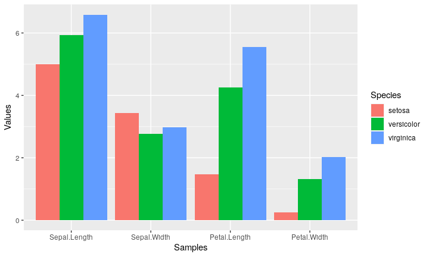

```r
iris_df %>%
    group_by(Species) %>%
    summarize_all(mean) %>%
    reshape2::melt(id.vars=c("Species"), variable.name = "Samples", value.name="Values") %>%
    ggplot(aes(Samples, Values, fill = Species)) +
           geom_bar(position="dodge", stat="identity")
```

## Outline

- Overview
- Install
- File Import and Export
- Usage
- Chaining (Pipes)
- **SQLite Databases**
- References

## SQLite Databases

`SQLite` is a lightweight relational database solution. The `RSQLite` package provides an easy to use interface to create, manage and query `SQLite` databases directly from R. Basic instructions for using `SQLite` from the command-line are available [here](https://www.sqlite.org/cli.html). A short introduction to `RSQLite` is available [here](https://github.com/rstats-db/RSQLite/blob/master/vignettes/RSQLite.Rmd).

## Loading data into SQLite databases

The following loads two `data.frames` derived from the `iris` data set (here `mydf1` and `mydf2`) into an SQLite database (here `test.db`).

```r
library(RSQLite)
unlink("test.db") # Delete any existing test.db
mydb <- dbConnect(SQLite(), "test.db") # Creates database file test.db
mydf1 <- data.frame(ids=paste0("id", seq_along(iris[,1])), iris)
mydf2 <- mydf1[sample(seq_along(mydf1[,1]), 10),]
dbWriteTable(mydb, "mydf1", mydf1)
dbWriteTable(mydb, "mydf2", mydf2)
```

### List names of tables in database

```r
dbListTables(mydb)
```

```
## [1] "mydf1" "mydf2"
```

**[ scroll down to continue ]**

### Import table into `data.frame`

```r
dbGetQuery(mydb, 'SELECT * FROM mydf2')
```

| ids | Sepal.Length | Sepal.Width | Petal.Length | Petal.Width | Species |
| --- | --- | --- | --- | --- | --- |
| id2 | 4.9 | 3.0 | 1.4 | 0.2 | setosa |
| id30 | 4.7 | 3.2 | 1.6 | 0.2 | setosa |
| id21 | 5.4 | 3.4 | 1.7 | 0.2 | setosa |
| id88 | 6.3 | 2.3 | 4.4 | 1.3 | versicolor |
| id61 | 5.0 | 2.0 | 3.5 | 1.0 | versicolor |
| id84 | 6.0 | 2.7 | 5.1 | 1.6 | versicolor |
| id144 | 6.8 | 3.2 | 5.9 | 2.3 | virginica |
| id95 | 5.6 | 2.7 | 4.2 | 1.3 | versicolor |
| id146 | 6.7 | 3.0 | 5.2 | 2.3 | virginica |
| id148 | 6.5 | 3.0 | 5.2 | 2.0 | virginica |

### Query database

```r
dbGetQuery(mydb, 'SELECT * FROM mydf1 WHERE "Sepal.Length" < 4.6')
```

| ids | Sepal.Length | Sepal.Width | Petal.Length | Petal.Width | Species |
| --- | --- | --- | --- | --- | --- |
| id9 | 4.4 | 2.9 | 1.4 | 0.2 | setosa |
| id14 | 4.3 | 3.0 | 1.1 | 0.1 | setosa |
| id39 | 4.4 | 3.0 | 1.3 | 0.2 | setosa |
| id42 | 4.5 | 2.3 | 1.3 | 0.3 | setosa |
| id43 | 4.4 | 3.2 | 1.3 | 0.2 | setosa |

### Join tables

The two tables can be joined on the shared `ids` column as follows.

```r
dbGetQuery(mydb, 'SELECT * FROM mydf1, mydf2 WHERE mydf1.ids = mydf2.ids')
```

| ids | Sepal.Length | Sepal.Width | Petal.Length | Petal.Width | Species | ids | Sepal.Length | Sepal.Width | Petal.Length | Petal.Width | Species |
| --- | --- | --- | --- | --- | --- | --- | --- | --- | --- | --- | --- |
| id2 | 4.9 | 3.0 | 1.4 | 0.2 | setosa | id2 | 4.9 | 3.0 | 1.4 | 0.2 | setosa |
| id21 | 5.4 | 3.4 | 1.7 | 0.2 | setosa | id21 | 5.4 | 3.4 | 1.7 | 0.2 | setosa |
| id30 | 4.7 | 3.2 | 1.6 | 0.2 | setosa | id30 | 4.7 | 3.2 | 1.6 | 0.2 | setosa |
| id61 | 5.0 | 2.0 | 3.5 | 1.0 | versicolor | id61 | 5.0 | 2.0 | 3.5 | 1.0 | versicolor |
| id84 | 6.0 | 2.7 | 5.1 | 1.6 | versicolor | id84 | 6.0 | 2.7 | 5.1 | 1.6 | versicolor |
| id88 | 6.3 | 2.3 | 4.4 | 1.3 | versicolor | id88 | 6.3 | 2.3 | 4.4 | 1.3 | versicolor |
| id95 | 5.6 | 2.7 | 4.2 | 1.3 | versicolor | id95 | 5.6 | 2.7 | 4.2 | 1.3 | versicolor |
| id144 | 6.8 | 3.2 | 5.9 | 2.3 | virginica | id144 | 6.8 | 3.2 | 5.9 | 2.3 | virginica |
| id146 | 6.7 | 3.0 | 5.2 | 2.3 | virginica | id146 | 6.7 | 3.0 | 5.2 | 2.3 | virginica |
| id148 | 6.5 | 3.0 | 5.2 | 2.0 | virginica | id148 | 6.5 | 3.0 | 5.2 | 2.0 | virginica |

## Outline

- Overview
- Install
- File Import and Export
- Usage
- Chaining (Pipes)
- SQLite Databases
- **References**

## References

“ Learn the tidyverse.” n.d. https://www.tidyverse.org/learn/. https://www.tidyverse.org/learn/.